# 042 Rainfall forecast for England

Wenxin Xu (uceswx0)

2022-05-08

### Load the required libraries

```r
library(maptools)
library(lattice)
library(spdep)
library(sp)
library(rgdal)
library(ggplot2)
library(gridExtra)
library(gstat)
library(spacetime)
library(forecast)
library(nnet)
library(caret)
library(kernlab)
```

## 1 data processing and analysis

### 1.1 load data

Here we import the data set and do some preliminary processing to generate the matrix.

```r
# read csv data
rainfall <- read.csv("data/rainfall.csv")

# transform to matrix
rainfall_matrix <- data.matrix(rainfall[, 7:ncol(rainfall)])

# add rowname
rownames(rainfall_matrix) <- rainfall[, "name"]
```

### 1.2 Time series decomposition

Here we use a line graph to visualise 72 months of time data for the Berkshire region.

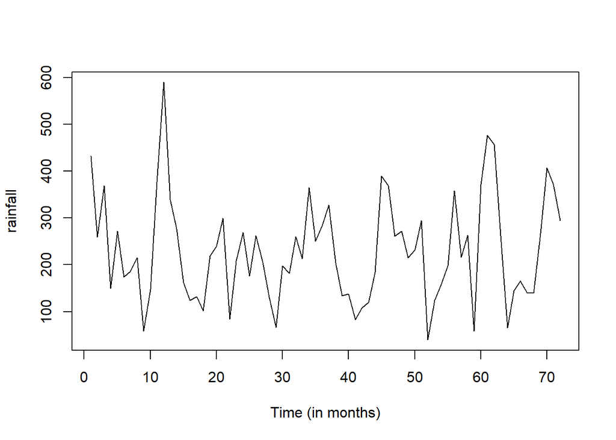

```r
# temporal data visulization
plot(rainfall_matrix["Berkshire",], ylab="rainfall", xlab="Time (in months)", type="l")
```

We need to examine the temporal autocorrelation of the data, first plotting the acf plot and finding that the data cycles in cycles of 12, i.e. the seasonal component has an order of 12, corresponding to 12 months of the year. The time lag of 12 needs to be differenced to eliminate the cyclical pattern and then the differenced acf plot needs to be analysed.

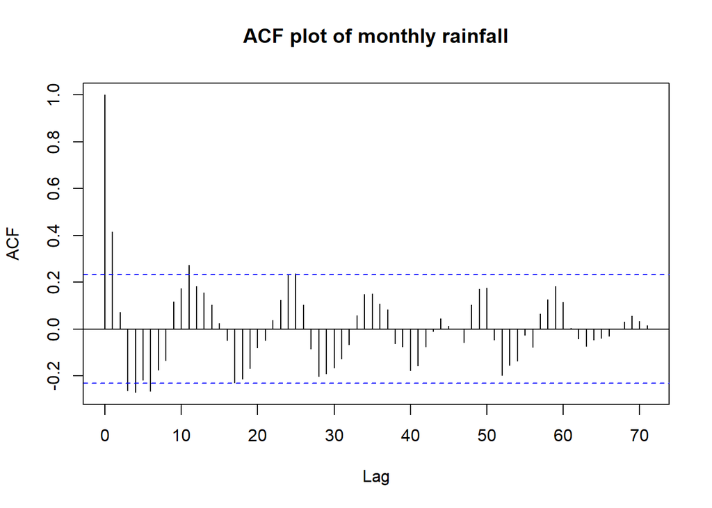

```r
# load function package
source("data/starima_package.R")

# acf
acf(rainfall_matrix["Berkshire",], lag.max=72, xlab="Lag", ylab="ACF", main="ACF plot of monthly rainfall")
```

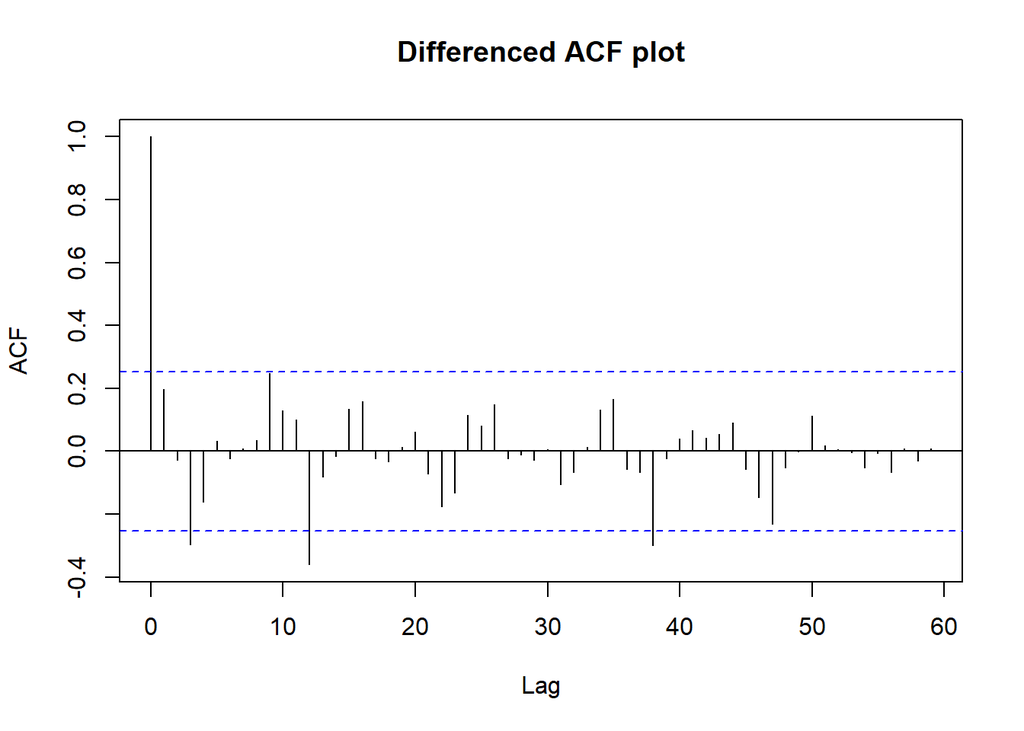

```r
# differenced acf
rainfall_diff <- diff(rainfall_matrix["Berkshire",], lag=12, differences=1)
acf(rainfall_diff, lag.max=72, xlab="Lag", ylab="ACF", main="Differenced ACF plot")
```

The differenced acf plot eliminates seasonal cycling in the data, with significant temporal autocorrelation at lags 3, 12 and 38.

We need to analyse the significance of the differenced pacf plot to determine the arima MA order.

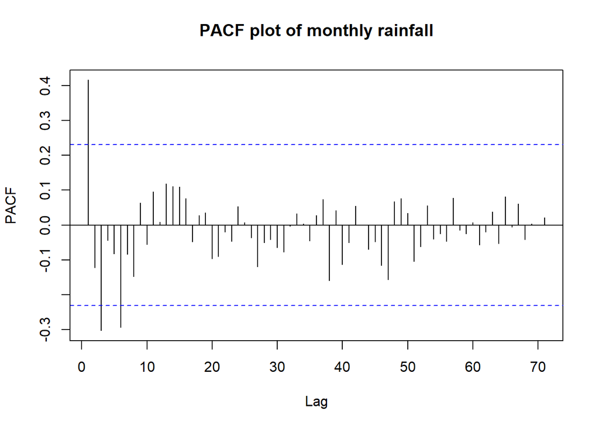

```r
# pacf
pacf(rainfall_matrix["Berkshire",], lag.max=72,xlab="Lag",ylab="PACF",main="PACF plot of monthly rainfall")
```

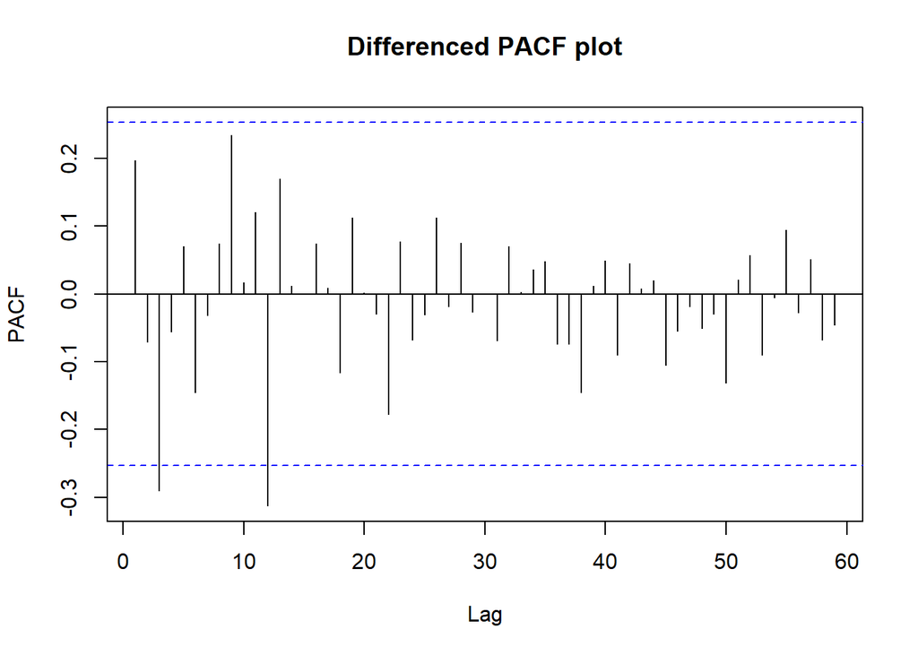

```r
# differenced pacf
pacf(rainfall_diff, lag.max=72, xlab="Lag", ylab="PACF",main="Differenced PACF plot")
```

The PACF plot has a clear peak at lag 12.

## 2 ARIMA

Using the ACF and PACF plots after differencing above, we can determine the parameters of the arima model as arima(1,0,1)(1,1,2)12. The following arima fit is performed using data from 1-60 as the training set.

```r
# fit
# arima(1,0,1)(1,1,2)12
timestart<-Sys.time()

fit_arima <- arima(rainfall_matrix["Berkshire",1:60], order=c(1,0,1),
                   seasonal=list(order=c(1,1,2), period=12))

# time
timeend<-Sys.time()
runningtime_ar <-timeend-timestart
print(runningtime_ar)
```

```
## Time difference of 2.336737 secs
```

The modeling time was calculated by fitting the arima model above. Next, the model is projected for the next 12 months and plotted against the true values, with the true values in black and the predicted values in red dashed lines.

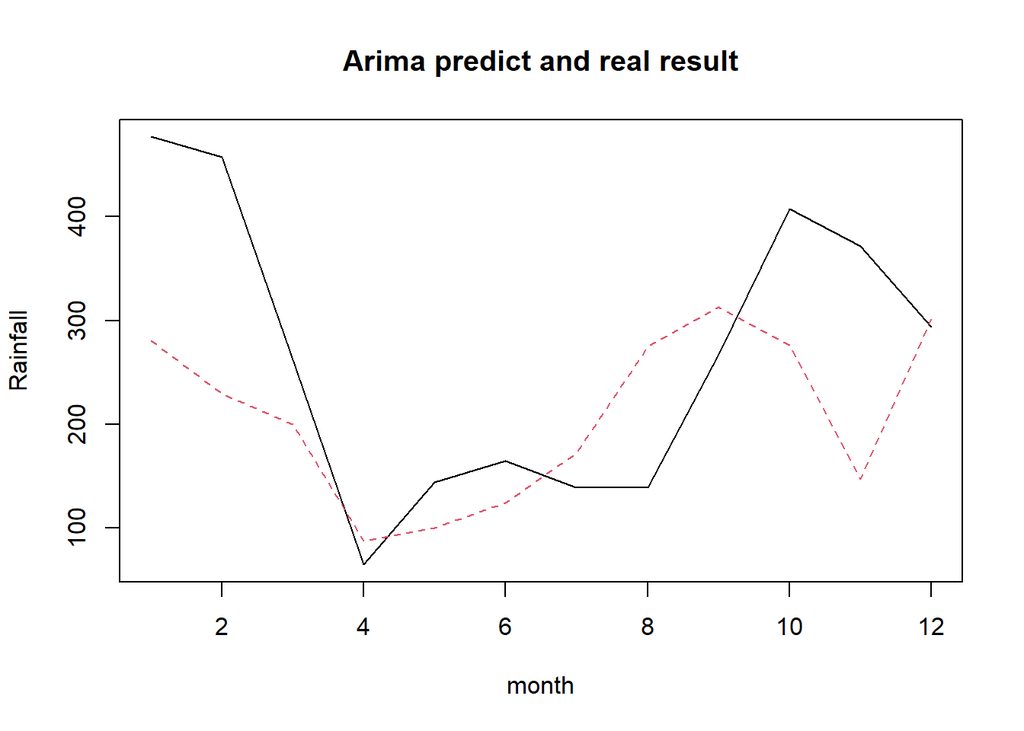

```r
# predict
pre_arima <- predict(fit_arima, n.ahead=12)
matplot(1:12,cbind(rainfall_matrix["Berkshire",61:72],pre_arima$pred),type="l",main="Arima predict and real result", xlab="month", ylab="Rainfall")
```

The predictions were generally in line with the trend. Next the arima model was evaluated parametrically, using the ormalized Root Mean Square Error, variance and running time as evaluation metrics for the calculations.

```r
# Evaluation
# Normalized Root Mean Square Error
NRMSE_ar <- NRMSE(res=fit_arima$residuals,
                   obs=rainfall_matrix["Berkshire",1:60])
NRMSE_ar
```

```
## [1] 0.841011
```

```r
# Variance
var_ar <- 0
count <- 0
for (fitted in pre_arima$pred){
  var_ar <- var_ar + (fitted-rainfall_matrix["Berkshire",61+count])^2
  count <- count+1
}
var_ar/count
```

```
## [1] 15643.72
```

```r
# time
print(runningtime_ar)
```

```
## Time difference of 2.336737 secs
```

## 3 ANN

For the ANN model the values from the first three months are used as input to predict the next month’s oracle, so the dataset needs to be reconstructed into data values for the four time points. The dataset is then sliced into a training set and a test set (12 months) and fitted using the ANN model for training. After several sets of tests, a decay factor of decay=5e-2, a neuron size=14 and a number of iterations maxit=1000 are selected.

```r
# Reconstructing the data matrix
m <- 3
x <- t(as.matrix(rainfall_matrix))
svm_data <- embed(x =x[,"Berkshire"], dimension = m+1)
colnames(svm_data) <- c("y_t-3","y_t-2","y_t-1","y_t")

# split dataset into train and test dataset
yTrain <- svm_data[1:57,1]
xTrain <- svm_data[1:57,-1]
yTest <- svm_data[58:nrow(svm_data),1]
xTest <- svm_data[58:nrow(svm_data),-1]

# train model
timestart<-Sys.time()
fit_ann <- nnet(xTrain, yTrain, decay=5e-2, linout = TRUE, size=14, maxit=1000)
```

```
## iter1000 value 68056.750440
```

```r
# train time
timeend<-Sys.time()
runningtime_ann <-timeend-timestart
print(runningtime_ann)
```

```
## Time difference of 0.1154699 secs
```

The trained ANN model is predicted and the prediction results are plotted against each other.

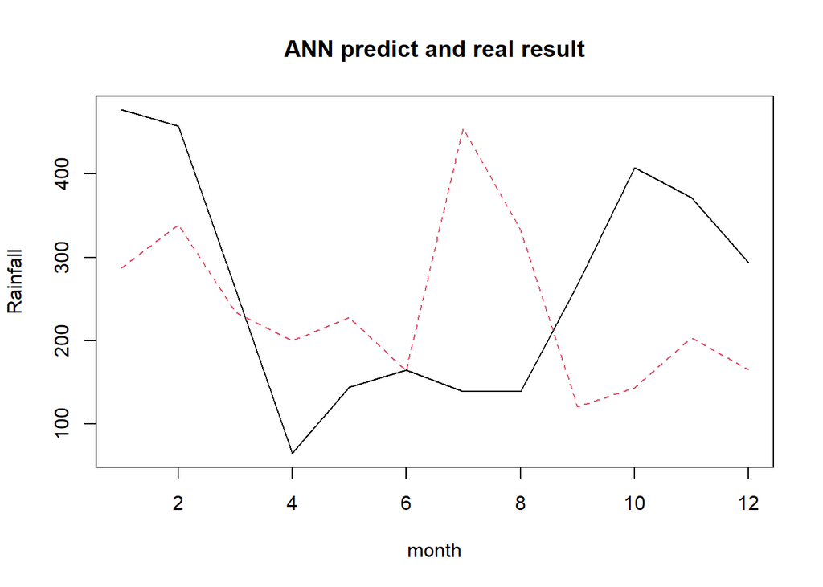

```r
#predict
pred_ann<-predict(fit_ann, xTest)

matplot(cbind(yTest, pred_ann[,]), type="l", main="ANN predict and real result", xlab="month",ylab="Rainfall")
```

For the ANN model fit evaluation, the same NRMSE, variance and training time were chosen as for Arima.

```r
# evaluation
# NRMSE
NRMSE_ann <- NRMSE(fit_ann$residuals,obs=yTest)
NRMSE_ann
```

```
## [1] 0.2184084
```

```r
# variance
var_ar <- 0
count <- 0
for (fitted in pred_ann[,]){
  var_ar <- var_ar + (fitted-yTest[1+count])^2
  count <- count+1
}
var_ar/count
```

```
## [1] 28990.21
```

```r
# time
print(runningtime_ann)
```

```
## Time difference of 0.1154699 secs
```

## 4 SVM

```r
# set cross_validation
cv <- trainControl(method = "cv", number=5)

# training model
# set dataset to find the most parameterized
SVR_grid <- expand.grid(.sigma=c(0.001, 0.01, 0.1,1), .C=c(1,10,100,1000))
# Cross-validation to find optimal parameters
timestart<-Sys.time()

SVR_fit <- train(xTrain, yTrain, method="svmRadial",
                      tuneGrid=SVR_grid, trControl=cv, type="eps-svr")
SVR_fit
```

```
## Support Vector Machines with Radial Basis Function Kernel
##
## 57 samples
##  3 predictor
##
## No pre-processing
## Resampling: Cross-Validated (5 fold)
## Summary of sample sizes: 45, 46, 45, 45, 47
## Resampling results across tuning parameters:
##
##   sigma  C     RMSE       Rsquared    MAE
##   0.001     1  100.71906  0.15493522   78.74308
##   0.001    10   96.77398  0.17564907   74.14171
##   0.001   100   94.98782  0.20414737   72.97360
##   0.001  1000   95.99730  0.20139297   73.88089
##   0.010     1   97.35771  0.16280731   75.02361
##   0.010    10   96.29004  0.18469153   74.51962
##   0.010   100   96.15448  0.18930243   76.02260
##   0.010  1000   97.60750  0.17540313   77.20511
##   0.100     1  100.22796  0.11598275   78.87330
##   0.100    10  101.21728  0.11900290   78.90662
##   0.100   100  120.99178  0.14040588   97.70057
##   0.100  1000  197.42393  0.13945102  146.40495
##   1.000     1  107.84332  0.06159354   87.54232
##   1.000    10  140.24922  0.07576462  113.78515
##   1.000   100  165.45211  0.02907350  134.21795
##   1.000  1000  256.95049  0.03527911  198.24266
##
## RMSE was used to select the optimal model using the smallest value.
## The final values used for the model were sigma = 0.001 and C = 100.
```

```r
# time
timeend<-Sys.time()
runningtime_svm <-timeend-timestart
print(runningtime_svm)
```

```
## Time difference of 2.036645 secs
```

Predictions are made and plotted using the trained model.

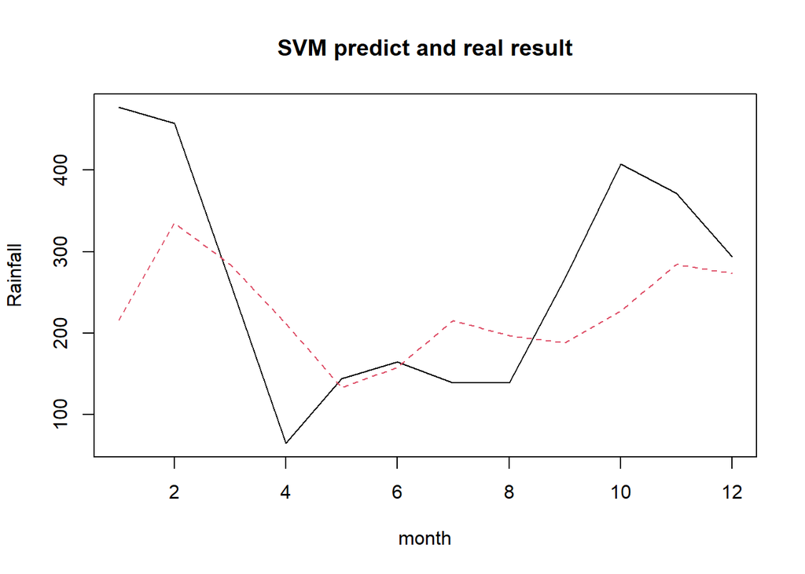

```r
# predict
# sigma = 0.01 and C = 100
svm_pred <- predict(SVR_fit, xTest)

matplot(cbind(yTest,svm_pred),ylab="Rainfall", xlab="month", main="SVM predict and real result", type="l")
```

The SVM results were evaluated. The SVM was unable to output residuals, so it was evaluated only for variance and training time.

```r
# evaluation
# Variance
var_ar <- 0
count <- 0
for (fitted in svm_pred){
  var_ar <- var_ar + (fitted-yTest[1+count])^2
  count <- count+1
}
var_ar/count
```

```
## [1] 13418.38
```

```r
# time
print(runningtime_svm)
```

```
## Time difference of 2.036645 secs
```